# QTM 151 Group 5 Final Project

# Insight 1: Economic Success Under Political Repression

## **1. Research Question**

**Is there a stable relationship between political empowerment and economic rights (measured through education and health) across country? Can we see regional patterns/differences for this relationship, and how have they changed from 2017 to 2021?**

## **2. Background for Readers & Rationale for Research Question**

When we think of a country's development, we often assume that economic development go hand in hand with political rights. Democracies are expected to care for their citizens not just by granting them the right to vote or speak freely, but also by providing education, health care, and other life-sustaining rights. But this might not always be the case, which is why we are interested in this research question. In fact, some governments may prioritize basic service delivery while deliberately restricting civil liberties. Exploring these exceptions allows us to better understand the complexity of governance models — and challenges the assumption that political freedom is always a prerequisite for social progress.

## **3. Variables**

Using the **Human Rights Measurement Initiative (HRMI)** dataset, we will explore the relationships and patterns between these variables:

### A. Empowerment Score

We measure a country's political freedom using the variable `empower_mean`, which captures a country's average score on four fundamental civil and political rights:

- Freedom of assembly and association
- Freedom of opinion and expression
- Right to participate in government
- Freedom of religion and belief

Although not explicitly specified in the HRMI data codebook, but since HRMI scores are on a scale of 1-10, a **lower score** (e.g., below 5) suggests that citizens in that country face greater restrictions on political participation and free expression.

### B. Economic Rights

According to the HRMI codebook, Economic and Social Rights are broken down into 5 categories: Education, Food, Health, Housing, Work. Specifically, HRMI encourages researchers to treat Education and Health as foundational pillars because they are already well-established in international treaties. Hence, we will use the variables `Education_All_IAScore` and `Health_All_IAScore` to assess a country's economic rights.

- `Education_All_IAScore`: captures the extent to which a country delivers on the right to education, adjusted for income level.
- `Health_All_IAScore`: captures the fulfillment of the right to health (including child survival, maternal health, and adult survival), also adjusted for income level.

Scores close to 100 mean that a country is doing **as well as can reasonably be expected**, given its income. These rights reflect a country’s progress toward the **International Covenant on Economic, Social and Cultural Rights (ICESCR)**

The explanations of the variables above are referenced from the HRMI dataset codebook!

## **4. Data Selection**

```python
import pandas as pd

cpr = pd.read_csv("../hrmi_data/csvfiles/cpr.csv")
esr = pd.read_csv("../hrmi_data/csvfiles/esr_hiy_incomeadjusted.csv")

cpr_filtered = cpr[['country', 'year', 'empower_mean']]
esr_filtered = esr[['Country', 'Year', 'HiY_Education_All_IAScore', 'HiY_Health_All_IAScore']]
esr_filtered = esr_filtered.rename(columns={'Country': 'country', 'Year': 'year'})

merged = pd.merge(cpr_filtered, esr_filtered, on=['country', 'year'], how='inner')

merged_filtered = pd.merge(cpr_filtered, esr_filtered, on=['country', 'year'])

region_map = {
    'United States': 'North America',
    'Canada': 'North America',
    'Germany': 'Europe',
    'France': 'Europe',
    'United Kingdom': 'Europe',
    'Australia': 'Oceania',
    'New Zealand': 'Oceania',
    'Brazil': 'South America',
    'Argentina': 'South America',
    'Mexico': 'Latin America',
    'India': 'South Asia',
    'Pakistan': 'South Asia',
    'Bangladesh': 'South Asia',
    'Japan': 'East Asia',
    'South Korea': 'East Asia',
    'China': 'East Asia',
    'Indonesia': 'Southeast Asia',
    'Vietnam': 'Southeast Asia',
    'Thailand': 'Southeast Asia',
    'Kenya': 'Africa',
    'Nigeria': 'Africa',
    'South Africa': 'Africa',
    # Add more countries as needed...
}

# Add region column
merged_filtered['region'] = merged_filtered['country'].map(region_map)

# Drop rows without region
regional_data = merged_filtered.dropna(subset=['region'])
```

## **5. Visualization & Interpretations**

## Graph 1: Scatterplot: General Overview of Political Empowerment VS. Economic Rights

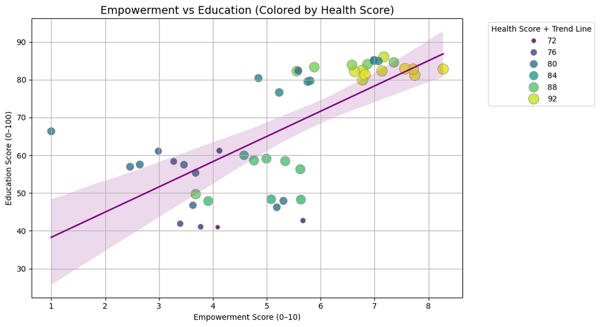

```python
import seaborn as sns
import matplotlib.pyplot as plt

merged_filtered = merged[(merged['year'] >= 2017) & (merged['year'] <= 2023)]

plt.figure(figsize=(10, 6))
scatter = sns.scatterplot(
    data=merged_filtered,
    x='empower_mean',
    y='HiY_Education_All_IAScore',
    hue='HiY_Health_All_IAScore',
    palette='viridis',
    size='HiY_Health_All_IAScore',
    sizes=(30, 200),
    alpha=0.8,
    edgecolor='gray'
)
sns.regplot(
    data=merged_filtered,
    x='empower_mean',
    y='HiY_Education_All_IAScore',
    scatter=False,
    color='purple',
    line_kws={'label': 'Linear Trend', 'linewidth': 2}
)

plt.title("Empowerment vs Education (Colored by Health Score)", fontsize=14)
plt.xlabel("Empowerment Score (0–10)")
plt.ylabel("Education Score (0–100)")
plt.legend(title='Health Score', bbox_to_anchor=(1.05, 1), loc='upper left')
plt.grid(True)
plt.tight_layout()
plt.legend(title='Health Score + Trend Line', bbox_to_anchor=(1.05, 1), loc='upper left')
plt.show()
```

Analysis: This scatter plot examines the relationship between countries’ **political empowerment scores** (x-axis) and their **education rights scores** (y-axis), with each point colored and sized by the corresponding **health rights score**.

The primary observation from this graph is that on average, countries with greater political freedom tend to achieve higher education fulfillment. This is also indicated by the purple trend line, which represents a linear regression fit, showing a clear positive correlation between political empowerment and education scores across 2017 to 2023.

Additionally, we also see that the size of the dots generally get larger with increasing empowerment scores, while the color of the dots also generally get more yellow with increasing empowerment scores, indicating that there is also a positive correlation between empowerment scores and health scores.

However, several outliers can be observed below in the lower quadrants (the dots that are not within the shade around the purple trend line, which stand for the 95% confidence interval). This suggests that some politically freer countries still underperform on education rights.

In conclusion, this pattern supports the general hypothesis that civil and political freedoms may contribute to better service delivery in education, but also reveals that **empowerment alone is not a guarantee of high education outcomes**. The visible dispersion also suggests that other structural or policy factors play a role, which could be explored in future research or country-specific case studies.

## Graph 2: Faceted Scatterplot: Political Empowerment Vs. Education Score from 2017-2023

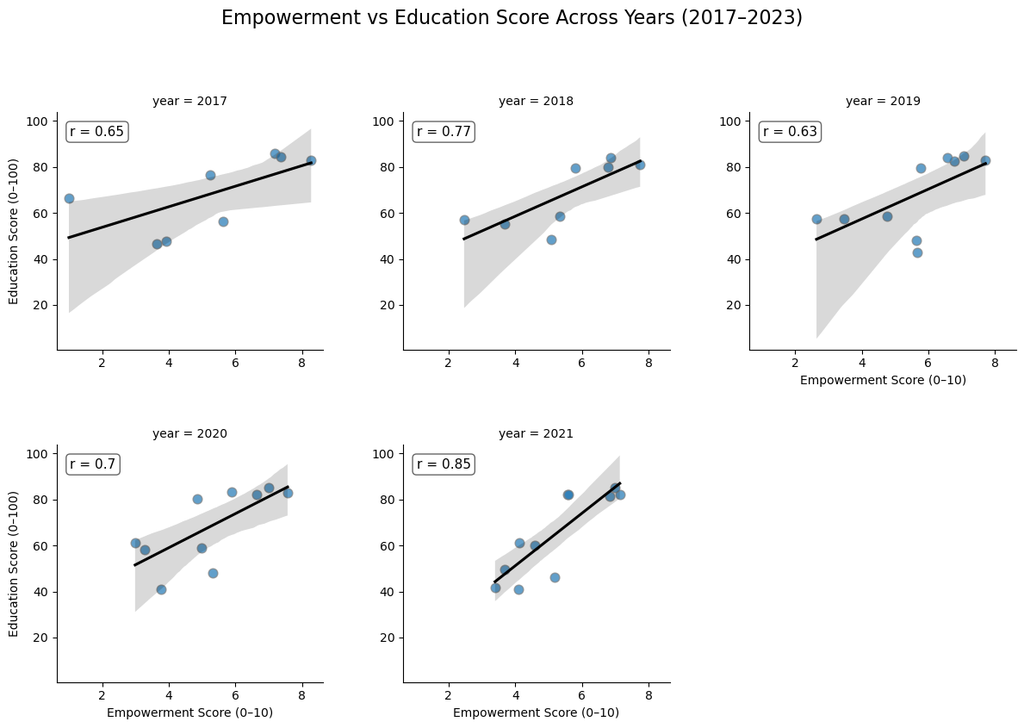

```python
from scipy.stats import pearsonr

g = sns.FacetGrid(
    data=merged_filtered,
    col='year',
    col_wrap=3,
    height=4,
    aspect=1
)

def scatter_with_trend_and_r(data, color, **kwargs):
    sns.regplot(
        data=data,
        x='empower_mean',
        y='HiY_Education_All_IAScore',
        scatter_kws={'alpha': 0.7, 's': 60, 'edgecolor': 'gray'},
        line_kws={'color': 'black'},
        ci=95
    )
    clean_data = data[['empower_mean', 'HiY_Education_All_IAScore']].dropna()
    if len(clean_data) >= 2:
        r, _ = pearsonr(clean_data['empower_mean'], clean_data['HiY_Education_All_IAScore'])
        r_display = round(r, 2)
        plt.text(0.05, 0.9, f"r = {r_display}", transform=plt.gca().transAxes,
                 fontsize=11, bbox=dict(boxstyle='round', facecolor='white', alpha=0.6))

g.map_dataframe(scatter_with_trend_and_r)

g.fig.suptitle("Empowerment vs Education Score Across Years (2017–2023)", fontsize=16, y=1.05)

for ax in g.axes.flatten():
    ax.set_xlabel("Empowerment Score (0–10)", fontsize=10)
    ax.set_ylabel("Education Score (0–100)", fontsize=10)
    ax.tick_params(labelbottom=True, labelleft=True)

g.fig.subplots_adjust(top=0.9, hspace=0.4, wspace=0.3)
plt.show()
```

Analysis: This graph is a detailed breakdown of the previous scatterplot (Graph 1) by factoring out each year's (from 2017 to 2021's) political empowerment vs. education score outcome for the countries. This allows us to capture the temporal stability and variation of these relationships, instead of an aggregated view of how education scores align with political freedom across long-term years.

All trend lines show a clear, positive, strong correlation between empowerment scores and education scores, which indicate that the relationship between these two variables are quite consistent over the course of 5 years. However, through the correlation coefficient, we still see differences in correlation strength. For example, r is stronger in year 2021 than years like 2017 and 2019, suggesting that there might exist external events that influenced the government's ability to deliver economic rights.

## Graph 3: Box plots: Regional Differences in Empowerment Scores AND Educational Scores

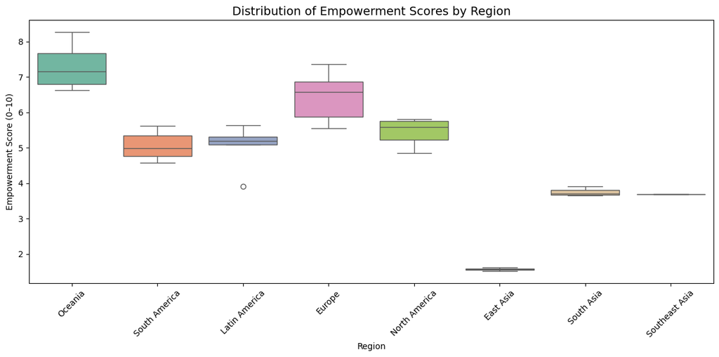

```python
plt.figure(figsize=(12, 6))
sns.boxplot(data=regional_data, x='region', y='empower_mean', palette='Set2')
plt.title("Distribution of Empowerment Scores by Region", fontsize=14)
plt.xlabel("Region")
plt.ylabel("Empowerment Score (0–10)")
plt.xticks(rotation=45)
plt.tight_layout()
plt.show()
```

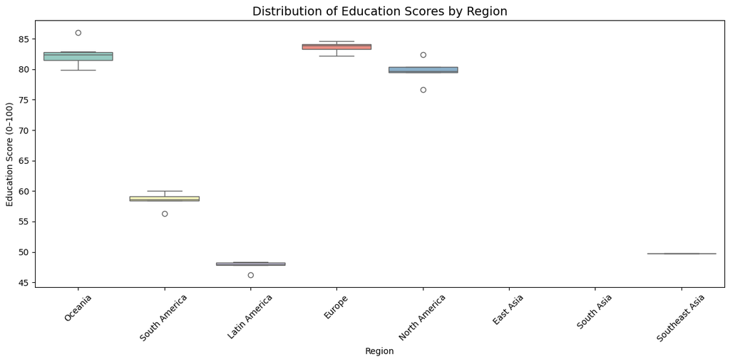

```python
plt.figure(figsize=(12, 6))
sns.boxplot(data=regional_data, x='region', y='HiY_Education_All_IAScore', palette='Set3')
plt.title("Distribution of Education Scores by Region", fontsize=14)
plt.xlabel("Region")
plt.ylabel("Education Score (0–100)")
plt.xticks(rotation=45)
plt.tight_layout()
plt.show()
```

Analysis: These two boxplots provide the differences in empowerment and education scores by region, which tries to answer the second part of our research question: *whether the relationship between political and economic rights varies across global regions*.

The first boxplot focuses on regional differences in empowerment scores. Regions like Oceania and Europe exhibit high empowerment scores (although having a slightly wider interquartile range), suggesting greater political freedom. In contrast, regions like East Asia, Southeast Asia, and South Asia have consistent lower scores, indicating a more restricted political environment.

The second boxplot focuses on regional differences in education scores. Again, Oceanina and Europe exhibits high education scores. This supports Graph 1 regarding the positive correlation between empowerment scores and education score. However, we also see another surprising finding! Some regions with high empowerment scores have lower education scores, like Latin America. This directly challanges our hypothesis that political empowerment goes hand in hand with economic rights. Additionally, we lack a representation for east asia and south asia, because the HRMI scores for the corresponding countries in these two regions are lacking.

Taken together, these two plots suggest that there is a regional structure to how political and economic rights relate. Regions with greater empowerment scores also tend to have higher education scores, and vice versa. This generally supports the hypothesis of a broad, global correlation--but the variation between regions imply that this relationship is not universally stable.

## **6. Conclusions**

The **KEY INSIGHT** is that while political empowerment are often positively correlated with economic rights, it does not guarantee a stable prediction. Our findings challenge the traditional assumption that democracy automatically ensures better living conditions, allowing us to reflect deeper about how human rights are realized in practice.

# Insight 2: Countries with Strong Protections Against Political Violence but Weak Guarantees of Food Security and Right to Housing(2021)

## **1. Research Question #1**

**Which countries in 2021 exhibit** strong protection** from political violence but **weak guarantees** of food security? Conversely, which do the opposite?**

## **2. Background for Readers & Rationale for Research Question #1**

We often assume that states that rigorously protect citizens’ physical integrity (no torture, disappearances, extrajudicial killings) also fulfill basic socioeconomic rights like food security. By identifying exceptions—countries that are better at protection but not doing as good on food, we challenge this assumption and uncouple civil/political and economic/social rights.

## **3. Variables**

We draw on the **Human Rights Measurement Initiative (HRMI)**:

1. **CPR** (Civil & Political Rights) – to measure protection from state violence
2. **ESR** (Economic & Social Rights) – to measure provision of basic services

We focus on:

- **Protection**: how well governments protect citizens from political violence
- **Food Security**: how well governments guarantee the right to food

### A. Protection from Political Violence

We use the **physint_mean** score from the **CPR** dataset.

> **physint_mean**  
> – **What it covers:**
> - Right to freedom from **arbitrary arrest** (`arrest`)
> - Right to freedom from **disappearance** (`disap`)
> - Right to freedom from **extrajudicial execution** (`exkill`)
> - Right to freedom from **torture and ill-treatment** (`tort`)

> – **Scale:** 0–10 (higher = better protection)  
> A **higher physint_mean** means that, on average, respondents judged a country to be highly effective at preventing state actors from carrying out political arrests, disappearances, executions, and torture.

### B. Food Security Provision

We compare two **ESR – Food** measures from HRMI’s **Global Best** dataset, one for **Low-&-Middle-Income (LMY)** countries and one for **High-Income (HiY)** countries:

> **LMY_Food_All_GBScore** – **Definition:** % of children (under 5) not stunted compared to the *best* performing LMY countries.
> - A score near **100** means the country is performing *as well as* the top LMY performers.
> - A score near **0** means very poor food security *even among LMY peers*.

> **HiY_Food_All_GBScore** – **Definition:** % of people with food security (household level) compared to the *best* performing HiY countries.
> - A score near **100** means the country matches the best food security in the high-income world.
> - A score near **0** indicates significant shortfalls *relative to HiY peers*.

## **4. Analysis**

We focus on the 2021 cross‐section. For each income group (LMY vs. HIY):

## **5. Data Selection**

```python
import pandas as pd
import matplotlib.pyplot as plt

#1. Load the relevant datasets
df_cpr = pd.read_csv("../hrmi_data/csvfiles/cpr.csv")
df_lmy = pd.read_csv("../hrmi_data/csvfiles/esr_lmy_globalbest.csv")
df_hiy = pd.read_csv("../hrmi_data/csvfiles/esr_hiy_globalbest.csv")

# keep only non-high-income in the LMY sample
df_lmy = df_lmy[df_lmy["High_Income_Country"] == 0]

# keep only high-income in the HIY sample
df_hiy = df_hiy[df_hiy["High_Income_Country"] == 1]

#2. Filter to the 2021 cross‐section
df_cpr = df_cpr[df_cpr["year"] == 2021]
df_lmy = df_lmy[df_lmy["Year"] == 2021]
df_hiy = df_hiy[df_hiy["Year"] == 2021]

#3. Merge CPR `physint_mean` into each ESR sample
#Join on `iso3c` (CPR) and `Country_Code` (ESR)
#Use an inner join to keep only countries present in both
df_lmy = pd.merge(
    df_lmy,
    df_cpr[["iso3c", "physint_mean"]],
    left_on="Country_Code",
    right_on="iso3c",
    how="inner"
)
df_hiy = pd.merge(
    df_hiy,
    df_cpr[["iso3c", "physint_mean"]],
    left_on="Country_Code",
    right_on="iso3c",
    how="inner"
)

#4. Rename Food‐score columns to generic names
df_lmy = df_lmy.rename(columns={"LMY_Food_All_GBScore": "food_score"})
df_hiy = df_hiy.rename(columns={"HiY_Food_All_GBScore": "food_score"})
```

## **6. Visualization & Interpretations**

```
LMY cut-offs:
  physint 35% = 5.04, 65% = 6.93
  food    35% = 62.18, 65% = 85.24

  Top countries with HIGH protection & LOW food (n=5):
        Country  physint_mean  food_score
Solomon Islands      8.818437   61.506276
       Kiribati      7.878201   82.984658
          Nepal      7.422262   59.274756
       Maldives      7.225001   78.438354
        Vanuatu      6.972990   59.693166

  Top countries with LOW protection & HIGH food (n=4):
   Country  physint_mean  food_score
     China      2.949840   96.359205
    Brazil      3.954124   92.763984
    Mexico      3.477816   82.349793
Bangladesh      2.773933   64.156206

============================================================

HIY cut-offs:
  physint 35% = 7.37, 65% = 8.14
  food    35% = 84.53, 65% = 89.92

  Top countries with HIGH protection & LOW food (n=0):
Empty DataFrame
Columns: [Country, physint_mean, food_score]
Index: []

  Top countries with LOW protection & HIGH food (n=2):
       Country  physint_mean  food_score
United Kingdom      7.196313   94.039116
 United States      5.036098   86.827303

============================================================
```

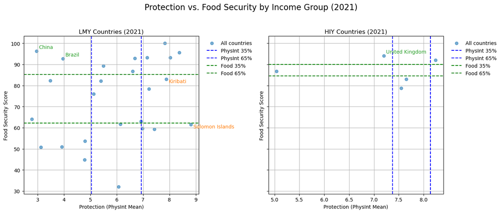

```python
# 5. Compute 35th and 65th percentile cut-offs for each sample
percentiles = {}
for name, df in [("LMY", df_lmy), ("HIY", df_hiy)]:
    x35 = df["physint_mean"].quantile(0.35)
    x65 = df["physint_mean"].quantile(0.65)
    y35 = df["food_score"].quantile(0.35)
    y65 = df["food_score"].quantile(0.65)
    percentiles[name] = {"x35": x35, "x65": x65, "y35": y35, "y65": y65}
    print(f"{name} cut-offs:")
    print(f"  physint 35% = {x35:.2f}, 65% = {x65:.2f}")
    print(f"  food    35% = {y35:.2f}, 65% = {y65:.2f}\n")

    # Print top countries tables
    high_low = df[(df["physint_mean"] >= x65) & (df["food_score"] <= y65)]
    low_high = df[(df["physint_mean"] <= x35) & (df["food_score"] >= y35)]
    print(f"  Top countries with HIGH protection & LOW food (n={len(high_low)}):")
    print(high_low.sort_values("physint_mean", ascending=False)[["Country","physint_mean","food_score"]].to_string(index=False))
    print(f"\n  Top countries with LOW protection & HIGH food (n={len(low_high)}):")
    print(low_high.sort_values("food_score", ascending=False)[["Country","physint_mean","food_score"]].to_string(index=False))
    print("\n" + "="*60 + "\n")

# 6. Plot Protection vs. Food Security and Annotate
fig, axes = plt.subplots(1, 2, figsize=(14,6), sharey=True)

for ax, (name, df) in zip(axes, [("LMY", df_lmy), ("HIY", df_hiy)]):
    p = percentiles[name]
    # Scatter all countries
    ax.scatter(df["physint_mean"], df["food_score"], alpha=0.6, label="All countries")

    # Quartile cut lines
    ax.axvline(p["x35"], color="blue", linestyle="--", label="PhysInt 35%")
    ax.axvline(p["x65"], color="blue", linestyle="--", label="PhysInt 65%")
    ax.axhline(p["y35"], color="green", linestyle="--", label="Food 35%")
    ax.axhline(p["y65"], color="green", linestyle="--", label="Food 65%")

    # Annotate top 2 HIGH protection & LOW food
    high_low = df[(df["physint_mean"] >= p["x65"]) & (df["food_score"] <= p["y65"])]
    for _, row in high_low.nlargest(2, "physint_mean").iterrows():
        ax.annotate(row["Country"],
                    (row["physint_mean"], row["food_score"]),
                    xytext=(5,-7), textcoords="offset points", color="C1")

    # Annotate top 2 LOW protection & HIGH food
    low_high = df[(df["physint_mean"] <= p["x35"]) & (df["food_score"] >= p["y65"])]
    for _, row in low_high.nlargest(2, "food_score").iterrows():
        ax.annotate(row["Country"],
                    (row["physint_mean"], row["food_score"]),
                    xytext=(5,5), textcoords="offset points", color="C2")

    ax.set_title(f"{name} Countries (2021)")
    ax.set_xlabel("Protection (PhysInt Mean)")
    ax.set_ylabel("Food Security Score")
    ax.grid(True)

    # move legend outside
    ax.legend(bbox_to_anchor=(1.02,1), loc="upper left", frameon=False)

plt.suptitle("Protection vs. Food Security by Income Group (2021)", fontsize=16)
plt.tight_layout(rect=[0,0,1,0.95])
plt.show()
```

## Analysis & Interpretation

### LMY Countries (2021)

- **Percentile cut-offs**
  - Protection (PhysInt mean): 35% = **5.04**, 65% = **6.93**
  - Food Security: 35% = **62.18**, 65% = **85.24**

[output not shown]

### HIY Countries (2021)

- **Percentile cut-offs**
  - Protection (PhysInt mean): 35% = **7.37**, 65% = **8.14**
  - Food Security: 35% = **84.53**, 65% = **89.92**

[output not shown]

### Scatter plot: What the Lines Mean

- **Vertical blue lines (PhysInt 35% & 65%)**  
  Divide countries by relative strength of *physical-integrity* rights (arbitrary arrest, torture, execution, disappearances).
- **Horizontal green lines (Food 35% & 65%)**  
  Divide countries by relative performance on *food security* (household-level food access).

### Key Takeaways

1. Among LMY countries, there are several cases (e.g., Solomon Islands, Nepal) of strong rights protections but weak food security, suggesting **uneven development** where civil-political gains have not yet translated into basic social needs.
2. Conversely, countries like China and Brazil achieved **high food security despite weaker protection**—perhaps reflecting state priorities on social provisioning over political freedoms.
3. Despite abundant resources to guarantee social-welfare outcomes like food, the UK and US have measurable shortfalls in safeguarding basic civil-political rights compared to other wealthy states.
4. Every high income country that ranks highly on physical-integrity rights also maintains at least moderate food security. There are no examples in the top 35% for protection who simultaneously fall into the bottom 35% for food. This uniform absence underscores that, at high levels of national wealth, basic social rights (food security) are not sacrificed in order to secure strong civil-political freedoms.

## **1. Research Question #2**

**Which countries in 2021 exhibit strong protection from political violence but weak guarantees of the right to housing? Conversely, which countries demonstrate strong housing guarantees but weaker protections?**

## **2. Background for Readers & Rationale for Research Question #2**

This analysis tests whether states that successfully prevent torture, disappearances, and arbitrary arrests also ensure access to housing. If not, it suggests a mismatch between civil-political rights and socio-economic rights, a critical consideration for understanding holistic human rights fulfillment.

## **3. Variables**

From the Human Rights Measurement Initiative (HRMI), we use:

### A. Civil & Political Rights (CPR)

- **physint_mean**: Composite measure of physical integrity rights (0–10; higher = better protection)

Captures protections against: Arbitrary arrest Disappearance Extrajudicial execution Torture or ill-treatment

### B. Economic & Social Rights (ESR) – Housing

Separate scores for:

LMY_Housing_All_GBScore for Low/Middle-Income (LMY) countries HiY_Housing_All_GBScore for High-Income (HIY) countries Scaled 0–100. A score near 100 means the country matches the best-performing peers in housing access and affordability.

```python
import pandas as pd
import matplotlib.pyplot as plt

# 1. Load data
df_cpr = pd.read_csv("../hrmi_data/csvfiles/cpr.csv")
df_lmy = pd.read_csv("../hrmi_data/csvfiles/esr_lmy_globalbest.csv")
df_hiy = pd.read_csv("../hrmi_data/csvfiles/esr_hiy_globalbest.csv")

# 2. Filter for correct year & income group
df_cpr = df_cpr[df_cpr["year"] == 2021]
df_lmy = df_lmy[(df_lmy["Year"] == 2021) & (df_lmy["High_Income_Country"] == 0)]
df_hiy = df_hiy[(df_hiy["Year"] == 2021) & (df_hiy["High_Income_Country"] == 1)]

# 3. Merge physint scores
df_lmy = pd.merge(df_lmy, df_cpr[["iso3c", "physint_mean"]],
                  left_on="Country_Code", right_on="iso3c", how="inner")
df_hiy = pd.merge(df_hiy, df_cpr[["iso3c", "physint_mean"]],
                  left_on="Country_Code", right_on="iso3c", how="inner")

# 4. Rename Housing Score columns
df_lmy = df_lmy.rename(columns={"LMY_Housing_All_GBScore": "housing_score"})
df_hiy = df_hiy.rename(columns={"HiY_Housing_All_GBScore": "housing_score"})
```

```python
# Compute cut-offs for analysis
percentiles = {}
for name, df in [("LMY", df_lmy), ("HIY", df_hiy)]:
    x35 = df["physint_mean"].quantile(0.35)
    x65 = df["physint_mean"].quantile(0.65)
    y35 = df["housing_score"].quantile(0.35)
    y65 = df["housing_score"].quantile(0.65)
    percentiles[name] = {"x35": x35, "x65": x65, "y35": y35, "y65": y65}

    print(f"{name} cut-offs:")
    print(f"  physint 35% = {x35:.2f}, 65% = {x65:.2f}")
    print(f"  housing 35% = {y35:.2f}, 65% = {y65:.2f}\n")

    high_low = df[(df["physint_mean"] >= x65) & (df["housing_score"] <= y35)]
    low_high = df[(df["physint_mean"] <= x35) & (df["housing_score"] >= y65)]

    print(f"  Top countries with HIGH protection & LOW housing (n={len(high_low)}):")
    print(high_low.sort_values("physint_mean", ascending=False)[["Country","physint_mean","housing_score"]].to_string(index=False))

    print(f"\n  Top countries with LOW protection & HIGH housing (n={len(low_high)}):")
    print(low_high.sort_values("housing_score", ascending=False)[["Country","physint_mean","housing_score"]].to_string(index=False))
    print("\n" + "="*60 + "\n")
```

```
LMY cut-offs:
  physint 35% = 5.04, 65% = 6.93
  housing 35% = 69.63, 65% = 91.15

  Top countries with HIGH protection & LOW housing (n=3):
        Country  physint_mean  housing_score
Solomon Islands      8.818437      43.445146
       Kiribati      7.878201      48.515208
        Vanuatu      6.972990      62.545170

  Top countries with LOW protection & HIGH housing (n=2):
Country  physint_mean  housing_score
  China      2.949840      92.332308
 Brazil      3.954124      91.943715

============================================================

HIY cut-offs:
  physint 35% = 7.37, 65% = 8.14
  housing 35% = 73.31, 65% = 73.31

  Top countries with HIGH protection & LOW housing (n=0):
Empty DataFrame
Columns: [Country, physint_mean, housing_score]
Index: []

  Top countries with LOW protection & HIGH housing (n=1):
       Country  physint_mean  housing_score
United Kingdom      7.196313       73.31477

============================================================
```

## **5. Visualization & Interpretations**

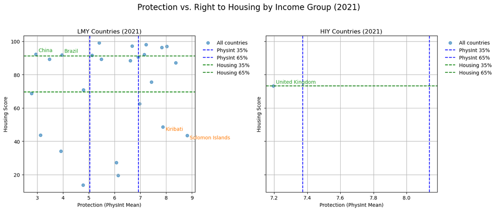

```python
fig, axes = plt.subplots(1, 2, figsize=(14,6), sharey=True)

for ax, (name, df) in zip(axes, [("LMY", df_lmy), ("HIY", df_hiy)]):
    p = percentiles[name]
    ax.scatter(df["physint_mean"], df["housing_score"], alpha=0.6, label="All countries")

    ax.axvline(p["x35"], color="blue", linestyle="--", label="PhysInt 35%")
    ax.axvline(p["x65"], color="blue", linestyle="--", label="PhysInt 65%")
    ax.axhline(p["y35"], color="green", linestyle="--", label="Housing 35%")
    ax.axhline(p["y65"], color="green", linestyle="--", label="Housing 65%")

    high_low = df[(df["physint_mean"] >= p["x65"]) & (df["housing_score"] <= p["y35"])]
    for _, row in high_low.nlargest(2, "physint_mean").iterrows():
        ax.annotate(row["Country"],
                    (row["physint_mean"], row["housing_score"]),
                    xytext=(5,-7), textcoords="offset points", color="C1")

    low_high = df[(df["physint_mean"] <= p["x35"]) & (df["housing_score"] >= p["y65"])]
    for _, row in low_high.nlargest(2, "housing_score").iterrows():
        ax.annotate(row["Country"],
                    (row["physint_mean"], row["housing_score"]),
                    xytext=(5,5), textcoords="offset points", color="C2")

    ax.set_title(f"{name} Countries (2021)")
    ax.set_xlabel("Protection (PhysInt Mean)")
    ax.set_ylabel("Housing Score")
    ax.grid(True)
    ax.legend(bbox_to_anchor=(1.02,1), loc="upper left", frameon=False)

plt.suptitle("Protection vs. Right to Housing by Income Group (2021)", fontsize=16)
plt.tight_layout(rect=[0,0,1,0.95])
plt.show()
```

## Analysis & Interpretation

### LMY Countries (2021)

**Cutoffs:**

- Protection (`physint_mean`): 35% = 5.04, 65% = 6.93
- Housing (`housing_score`): 35% = 69.63, 65% = 91.15

| Quadrant | Countries |
| --- | --- |
| High Protection & Low Housing | Kiribati, Solomon Islands, Vanuatu |
| Low Protection & High Housing | Brazil, China |

**Interpretation:**

- **High Protection / Low Housing:** These Pacific island nations show strong civil protections (`physint > 6.9`) but very low housing scores, indicating potential urban planning, affordability, or infrastructure deficiencies.
  - *Example:* Solomon Islands – physint ≈ 8.8, housing ≈ 43.4
- **Low Protection / High Housing:** Brazil and China display high housing scores (≈91–92) but fall below the 35th percentile in political rights.
  - *Example:* China – physint ≈ 2.9, housing ≈ 92.3

### HIY Countries (2021)

**Cutoffs:**

- Protection (`physint_mean`): 35% = 7.37, 65% = 8.14
- Housing (`housing_score`): 35% = 73.31 (NB: 65th = also 73.31 → narrow distribution)

| Quadrant | Countries |
| --- | --- |
| High Protection & Low Housing | None |
| Low Protection & High Housing | United Kingdom |

**Interpretation:**

### Scatter Plot: What the Lines Mean

- **Vertical blue lines (PhysInt 35% & 65%)**  
  Divide countries by relative strength of *physical-integrity rights* (freedom from arbitrary arrest, torture, disappearance, and execution).
- **Horizontal green lines (Housing 35% & 65%)**  
  Divide countries by relative performance on the *right to housing* (availability, affordability, and adequacy compared to best-performing peers).

# Insight 3: Economic Gender Inequality Regarding Social Rights

## **1. Research Question**

**In which countries is the gender gap (male vs. female) in economic and social rights (education, health, Food Security) the largest? Is there a trend for the gender gap from 2017 to 2021? Are large gender gaps concentrated in specific income groups?**

## **2. Background for Readers & Rationale for Research Question**

While global attention has been paid to women's rights and gender equality, actual gaps in access to essential services like education, health, and housing persist across many countries. Identifying the concentration of these gaps can inform global aid, policy focus, and advocacy. Specifically, our goal is to determine whether these gaps follow clear patterns based on national income levels or geographic region.

## **3. Variables**

Using the **Human Rights Measurement Initiative (HRMI)** dataset, we examine gender gaps by comparing male and female scores across three key economic rights:

Using the Human Rights Measurement Initiative (HRMI) datasets, we examine gender gaps by comparing male and female scores across three core economic rights: education, health, and food security. All scores are income-adjusted, allowing fair comparisons across countries with different income levels.

### A. Education Score

We use the variables: `HiY_Education_Male_IAScore`, `HiY_Education_Female_IAScore`

`LMY_Education_Male_IAScore`, `LMY_Education_Female_IAScore`

These variables are taken from the HRMI esr_sex_disaggregated dataset and reflect how well countries fulfill the right to education for males and females, under both the High Income (HiY) and Low/Middle Income (LMY) benchmarks. Gender Gap is calculated as Male score – Female score. A positive value means males are better fulfilling their right to education than females. A score closer to 100 indicates a country is meeting expectations for education based on its income level.

### B. Health Score

We use the variables:

`AdultSurvival_Male_IAScore`, `AdultSurvival_Female_IAScore`

These come from the HRMI esr_sex_disaggregated dataset and represent the right to health for men and women, incorporating indicators like child survival, maternal health, and adult survival. Gender gaps are computed the same way (Male – Female). Scores are adjusted to reflect expected performance for each country’s income level.

### C. Food Security Score

We use the variables:

`FoodSecure_Male_IAScore`, `FoodSecure_Female_IAScore`

These indicators capture how well men and women are achieving the right to food security, again based on HRMI’s income-adjusted expectations. A higher score means stronger protection of this right.

The explanations of the variables above are referenced from the HRMI dataset codebook!

## **4. Data Selection**

```python
import pandas as pd
import numpy as np
import matplotlib.pyplot as plt
import seaborn as sns
from matplotlib.colors import Normalize
from matplotlib.cm import ScalarMappable


# Load dataset

df = pd.read_csv("../hrmi_data/csvfiles/esr_sex_disaggregated.csv")
```

```python
df_subset = df[[
    'Country', 'Year',
    'HiY_Education_Male_IAScore', 'HiY_Education_Female_IAScore',
    'LMY_Education_Male_IAScore', 'LMY_Education_Female_IAScore',
    'AdultSurvival_Male_IAScore', 'AdultSurvival_Female_IAScore',
    'FoodSecure_Male_IAScore', 'FoodSecure_Female_IAScore'
]].copy()

# Create education subset with both HiY and LMY standards
edu_hiy = df_subset[['Country', 'Year', 'HiY_Education_Male_IAScore', 'HiY_Education_Female_IAScore']].copy()
edu_hiy.rename(columns={
    'HiY_Education_Male_IAScore': 'Male',
    'HiY_Education_Female_IAScore': 'Female'
}, inplace=True)
edu_hiy['Right'] = 'Education (HiY)'

edu_lmy = df_subset[['Country', 'Year', 'LMY_Education_Male_IAScore', 'LMY_Education_Female_IAScore']].copy()
edu_lmy.rename(columns={
    'LMY_Education_Male_IAScore': 'Male',
    'LMY_Education_Female_IAScore': 'Female'
}, inplace=True)
edu_lmy['Right'] = 'Education (LMY)'

# Final combined education DataFrame
edu = pd.concat([edu_hiy, edu_lmy], ignore_index=True)

# Create health subset
health = df_subset[['Country', 'Year', 'AdultSurvival_Male_IAScore', 'AdultSurvival_Female_IAScore']].copy()
health.rename(columns={
    'AdultSurvival_Male_IAScore': 'Male',
    'AdultSurvival_Female_IAScore': 'Female'
}, inplace=True)
health['Right'] = 'Health'

# Create food security subset
food = df_subset[['Country', 'Year', 'FoodSecure_Male_IAScore', 'FoodSecure_Female_IAScore']].copy()
food.rename(columns={
    'FoodSecure_Male_IAScore': 'Male',
    'FoodSecure_Female_IAScore': 'Female'
}, inplace=True)
food['Right'] = 'Food Security'

# Combine all three into one DataFrame
df_pivot = pd.concat([edu, health, food], ignore_index=True)


df_long = pd.melt(
    df_pivot,
    id_vars=['Country', 'Year', 'Right'],
    value_vars=['Male', 'Female'],
    var_name='Gender',
    value_name='Score'
)

df_gap_calc = df_long.pivot_table(
    index=['Country', 'Year', 'Right'],
    columns='Gender',
    values='Score'
).reset_index()

df_gap_calc['Gap'] = df_gap_calc['Male'] - df_gap_calc['Female']


df_long = df_long.merge(
    df_gap_calc[['Country', 'Year', 'Right', 'Gap']],
    on=['Country', 'Year', 'Right'],
    how='left'
)


print(df_long.head())


df_pivot = df_long.pivot_table(
    index=['Country', 'Year', 'Right'],
    columns='Gender',
    values='Score'
).reset_index()
df_pivot['Gap'] = df_pivot['Male'] - df_pivot['Female']
```

```
  Country  Year            Right Gender  Score  Gap
0   Aruba  1990  Education (HiY)   Male    NaN  NaN
1   Aruba  1991  Education (HiY)   Male    NaN  NaN
2   Aruba  1992  Education (HiY)   Male    NaN  NaN
3   Aruba  1993  Education (HiY)   Male    NaN  NaN
4   Aruba  1994  Education (HiY)   Male    NaN  NaN
```

## **5. Visualization & Interpretations**

## Graph 1-3: Barplot – Top 15 Gender Gaps in Education/Health/Food Security (Male – Female), 2021

## Graph 1: Education

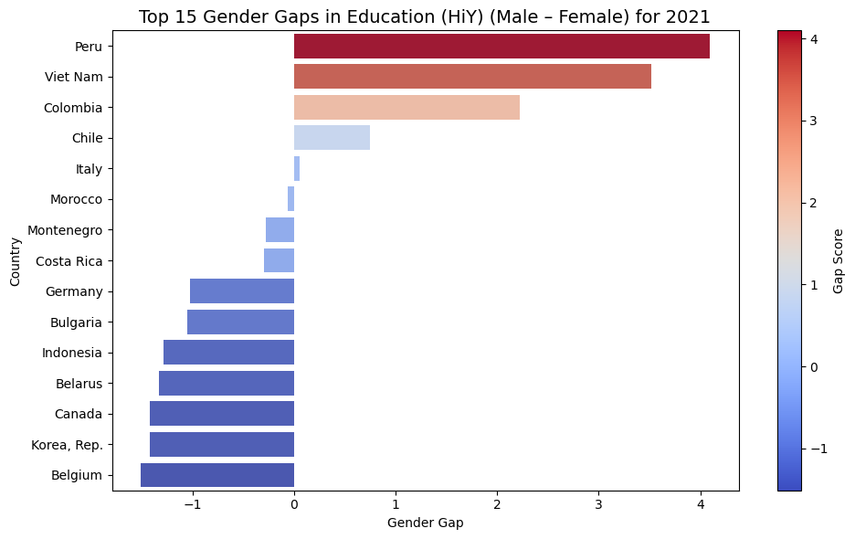

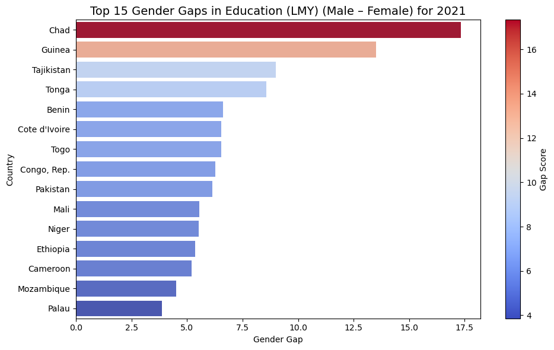

```python
from matplotlib.colors import Normalize
from matplotlib.cm import ScalarMappable
import seaborn as sns
import matplotlib.pyplot as plt

# Filter for 2021
for edu_type in ['Education (HiY)', 'Education (LMY)']:
    edu_topgap = df_pivot[(df_pivot['Right'] == edu_type) & (df_pivot['Year'] == 2021)].copy()
    edu_topgap = edu_topgap.dropna(subset=['Gap'])
    edu_topgap = edu_topgap[edu_topgap['Gap'] != 0]

    if edu_topgap.empty:
        print(f"No data available for {edu_type} in 2021.")
        continue


    edu_topgap = edu_topgap.sort_values(by='Gap', ascending=False).head(15)


    norm = Normalize(vmin=edu_topgap['Gap'].min(), vmax=edu_topgap['Gap'].max())
    sm = ScalarMappable(cmap='coolwarm', norm=norm)
    colors = [sm.to_rgba(g) for g in edu_topgap['Gap']]


    fig, ax = plt.subplots(figsize=(10, 6))
    sns.barplot(data=edu_topgap, y='Country', x='Gap', ax=ax, palette=colors)

    ax.set_title(f'Top 15 Gender Gaps in {edu_type} (Male – Female) for 2021', fontsize=14)
    ax.set_xlabel('Gender Gap')
    ax.set_ylabel('Country')

    sm.set_array([])
    fig.colorbar(sm, ax=ax, label='Gap Score')

    plt.tight_layout()
    plt.show()
```

Analysis: The two graphs reveal stark contrasts in gender gaps in education between high-income (HiY) and low-/middle-income (LMY) countries.

## Graph 2: Health

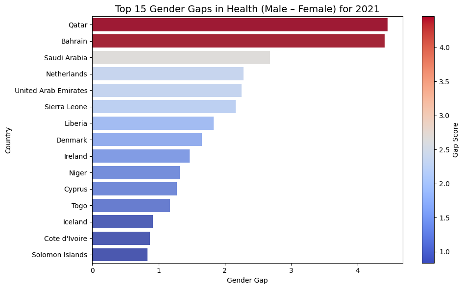

```python
import matplotlib.pyplot as plt
from matplotlib.colors import Normalize
from matplotlib.cm import ScalarMappable
import seaborn as sns


health_topgap = df_pivot[(df_pivot['Right'] == 'Health') & (df_pivot['Year'] == 2021)].copy()
health_topgap = health_topgap.dropna(subset=['Gap'])
health_topgap = health_topgap[health_topgap['Gap'] != 0]


health_topgap = health_topgap.sort_values(by='Gap', ascending=False).head(15)


norm_health = Normalize(vmin=health_topgap['Gap'].min(), vmax=health_topgap['Gap'].max())
sm_health = ScalarMappable(cmap='coolwarm', norm=norm_health)
colors_health = [sm_health.to_rgba(g) for g in health_topgap['Gap']]


fig, ax = plt.subplots(figsize=(10, 6))
sns.barplot(data=health_topgap, y='Country', x='Gap', ax=ax, palette=colors_health)

ax.set_title('Top 15 Gender Gaps in Health (Male – Female) for 2021', fontsize=14)
ax.set_xlabel('Gender Gap')
ax.set_ylabel('Country')

sm_health.set_array([])
fig.colorbar(sm_health, ax=ax, label='Gap Score')

plt.tight_layout()
plt.show()
```

Interestingly, the list includes both wealthy nations (e.g., Netherlands, Denmark, Ireland) and low-income countries (e.g., Sierra Leone, Liberia, Niger). This suggests that higher income alone does not eliminate gender disparities in health.These gaps may reflect differences in access to healthcare, cultural or legal barriers to women's health services, or systemic inequality in how health resources are distributed and prioritized. Cross-country variation shows that economic development and gender equity in health do not always go hand-in-hand.

## Graph 3: Food Security

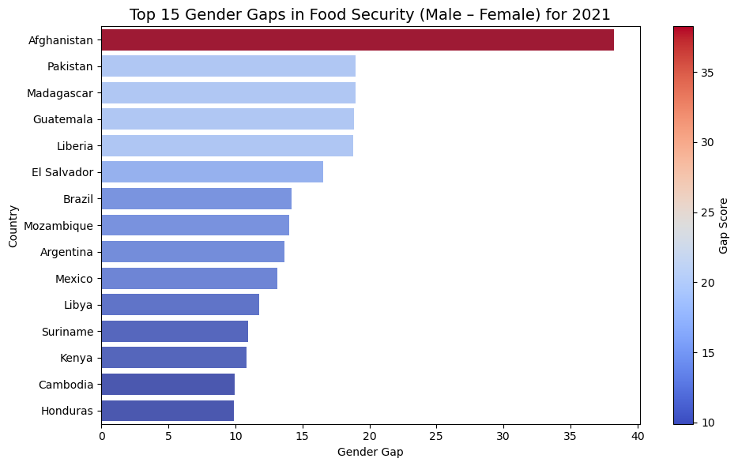

```python
import matplotlib.pyplot as plt
from matplotlib.colors import Normalize
from matplotlib.cm import ScalarMappable
import seaborn as sns


food_topgap = df_pivot[(df_pivot['Right'] == 'Food Security') & (df_pivot['Year'] == 2021)].copy()
food_topgap = food_topgap.dropna(subset=['Gap'])
food_topgap = food_topgap[food_topgap['Gap'] != 0]


food_topgap = food_topgap.sort_values(by='Gap', ascending=False).head(15)


norm_food = Normalize(vmin=food_topgap['Gap'].min(), vmax=food_topgap['Gap'].max())
sm_food = ScalarMappable(cmap='coolwarm', norm=norm_food)
colors_food = [sm_food.to_rgba(g) for g in food_topgap['Gap']]


fig, ax = plt.subplots(figsize=(10, 6))
sns.barplot(data=food_topgap, y='Country', x='Gap', ax=ax, palette=colors_food)

ax.set_title('Top 15 Gender Gaps in Food Security (Male – Female) for 2021', fontsize=14)
ax.set_xlabel('Gender Gap')
ax.set_ylabel('Country')


sm_food.set_array([])
fig.colorbar(sm_food, ax=ax, label='Gap Score')

plt.tight_layout()
plt.show()
```

Analysis: This chart shows the 15 countries with the largest gender gaps in food security fulfillment, calculated as Male – Female scores. Afghanistan displays an extreme gap of nearly 40 points, far surpassing other countries—indicating critical inequality in food access between men and women.

Countries span Latin America (e.g., Guatemala, Argentina), Africa (e.g., Kenya, Mozambique), and Asia (e.g., Pakistan, Afghanistan)—pointing to a widespread issue across income levels and regions.These gaps may reflect discriminatory food allocation, cultural norms, or crises that disproportionately affect women (e.g., conflict, displacement).Addressing food security requires gender-sensitive policies even in broader poverty interventions.

## Graph 4: Line Plot – Trends in Gender Gap Across Education, Health, and Food Security (2017–2021)

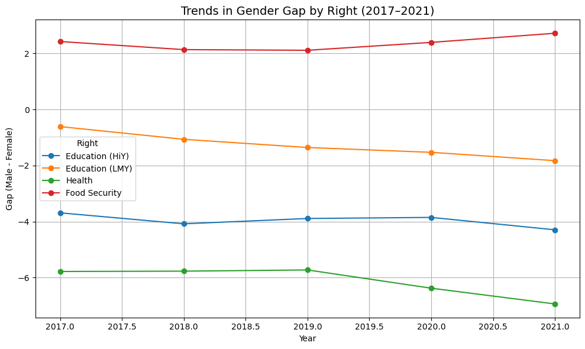

```python
# Include HiY and LMY education separately
target_rights = ['Education (HiY)', 'Education (LMY)', 'Health', 'Food Security']
trend_df = df_pivot[df_pivot['Right'].isin(target_rights) & df_pivot['Year'].between(2017, 2021)]

# Compute average gender gap per year and right
trend_avg = trend_df.groupby(['Year', 'Right'])[['Male', 'Female']].mean().reset_index()
trend_avg['Gap'] = trend_avg['Male'] - trend_avg['Female']

# Plotting
plt.figure(figsize=(10, 6))

for right in target_rights:
    subset = trend_avg[trend_avg['Right'] == right]
    plt.plot(subset['Year'], subset['Gap'], marker='o', label=right)

plt.title('Trends in Gender Gap by Right (2017–2021)', fontsize=14)
plt.xlabel('Year')
plt.ylabel('Gap (Male - Female)')
plt.grid(True)
plt.legend(title='Right')
plt.tight_layout()
plt.show()
```

Analysis: This line graph presents the gender gap trends in four key rights—Education (HiY), Education (LMY), Health, and Food Security—from 2017 to 2021. The gender gap is calculated as Male – Female, so negative values indicate better outcomes for females, while positive values suggest a male advantage.

Education (HiY): High-income countries show a persistent female advantage in education, with a slightly widening negative gap over time. This suggests that girls and women in high-income nations are increasingly outperforming males in access to or fulfillment of education rights.

Education (LMY): Low- and middle-income countries also show a female advantage, though the gap is less negative than in HiY countries. The trend here is also downward, indicating that females are seeing increasing fulfillment relative to males in recent years.

Health: The gender gap in health remains consistently and substantially negative, meaning females enjoy significantly higher fulfillment of health rights globally. The gap widens slightly after 2019, highlighting growing disparities favoring females, possibly due to differential improvements in maternal or child health outcomes.

Food Security: This is the only right with a positive gap, indicating a persistent male advantage. The slight upward trend suggests the gap is widening, meaning males are increasingly more likely to enjoy adequate food access compared to females—particularly concerning in lower-income contexts.

## Graph 5: Boxplot Comparison of Economic Rights by Income Group (2021)

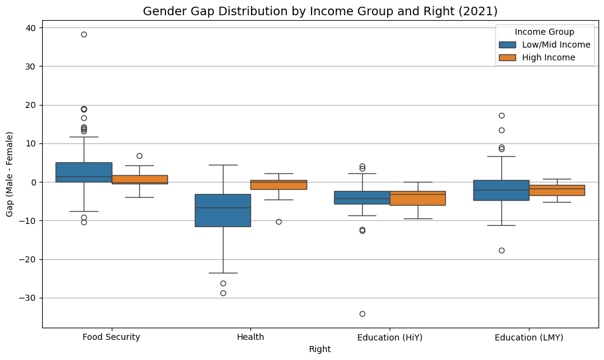

```python
import seaborn as sns
import matplotlib.pyplot as plt

# Expanded list of high-income countries
high_income_countries = [
    'United States', 'Canada', 'Germany', 'France', 'United Kingdom',
    'Australia', 'Japan', 'South Korea', 'Italy', 'Spain',
    'Netherlands', 'Sweden', 'Norway', 'Denmark', 'Finland',
    'Belgium', 'Austria', 'Switzerland', 'Singapore', 'New Zealand',
    'Ireland', 'Iceland', 'Luxembourg', 'Israel', 'Portugal'
]


def assign_income_group(country):
    return 'High Income' if country in high_income_countries else 'Low/Mid Income'


df_pivot['Income Group'] = df_pivot['Country'].apply(assign_income_group)


df_2021 = df_pivot[df_pivot['Year'] == 2021].copy()


plt.figure(figsize=(10, 6))
sns.boxplot(data=df_2021, x='Right', y='Gap', hue='Income Group')
plt.title('Gender Gap Distribution by Income Group and Right (2021)', fontsize=14)
plt.ylabel('Gap (Male - Female)')
plt.xlabel('Right')
plt.grid(True, axis='y')
plt.legend(title='Income Group')
plt.tight_layout()
plt.show()
```

Analysis: This boxplot compares the distribution of three economic rights—Education, Health, and Food Security—between High Income and Low/Mid Income countries for the year 2021.

1. Health

Low/Mid-income countries show a much larger negative gap, meaning females are significantly better off in health outcomes compared to males. High-income countries show near parity with smaller spread, indicating less pronounced gender disparities.

2. Education

Both income groups have negative median gaps, showing that females tend to perform better. Low/Mid-income countries display greater variability, with some extreme male advantages appearing as outliers.

3. Food Security

The median gap is near zero for high-income countries, suggesting relative gender equality in food access. In Low/Mid-income countries, there's greater variability and more extreme male advantage, with several countries showing males much better off than females.

## **6. Conclusions**

Through an examination of gender gaps in education, health, and food security from 2017 to 2021, this analysis uncovers clear disparities in rights fulfillment between males and females, shaped by both income level and domain of rights.

Health rights consistently favored females, particularly in lower-income contexts, where males had notably lower fulfillment scores. This trend was reflected in the strong negative average gender gap over time. In food security, while high-income countries approached gender parity, many lower-income countries exhibited substantial male advantages, with Afghanistan standing out with a gap near 40 points.

Over the five-year period, health and education gaps widened, with females increasingly outperforming males on average. Food security remained the only right with a positive average gender gap, indicating persistent male advantage globally.

**KEY INSIGHT** Economic development raises overall fulfillment, but does not close gender gaps. Across all domains, high-income countries had higher average scores, yet disparities between men and women remained. This suggests that progress toward gender equity requires more than economic growth—it demands deliberate, gender-focused policy action, particularly in education and food access for girls and women in low/mid-income countries.